# Discrete measurements · Corleone.jl

## Setup

We will use `Corleone` and `CorleoneOED` to model the optimal experimental design problem.

```julia
using Corleone, CorleoneOED
```

Additionally, we will need the following packages

- `LuxCore` and `Random` for basic setup functions
- `OrdinaryDiffEqTsit5` as an adaptive solver for the related ODEProblem
- `SymbolicIndexingInterface` to conveniently access variables and controls of the solution
- `Optimization`, `OptimizationMOI`, `Ipopt`, and `ComponentArrays` to setup and solve the optimization problem
- `CairoMakie` to plot the solution

```julia
using LuxCore
using Random
using OrdinaryDiffEqTsit5
using SymbolicIndexingInterface
using Optimization
using OptimizationMOI
using Ipopt
using ComponentArrays
using CairoMakie
```

## Define the dynamics

```julia
function compartmental(du, u, p, t)
    θ₁, θ₂, θ₃ = p
    du[1] = θ₃ * (-θ₁ * exp(-θ₁ * t) + θ₂ * exp(-θ₂ * t))
    return
end

tspan = (0.0, 50.0)
u0 = [0.0]
p0 = [0.05884, 4.298, 21.8]
prob = ODEProblem(compartmental, u0, tspan, p0)
```

```
ODEProblem with uType Vector{Float64} and tType Float64. In-place: true
Non-trivial mass matrix: false
timespan: (0.0, 50.0)
u0: 1-element Vector{Float64}:
 0.0
```

## Construct the discrete measurement `OEDLayer`

Constructing the `OEDLayer` with discrete measurement model is done via the specialization `{true}`. As there are also no other controls acting on the system and the initial values are fixed, this is another special case of OED, i.e., the solution of the differential equation is fixed for some parts of the variables, namely the original differential states and their sensitivity with respect to the parameters. `CorleoneOED` takes this into account to accelerate computations by not integrating these fixed differential states in each iteration.

```julia
measurement_points = [0.0, 0.166, 0.333, 0.5, 0.666, 1.0, 1.5, 2.0, 2.5, 3.0, 4.0, 5.0, 6.0, 8.0, 10.0, 12.0, 24.0, 30.0, 48.0]
w_init = 0.5 * ones(length(measurement_points))

oed = OEDLayer{true}(
    prob, Tsit5(),
    params = [1, 2, 3],
    bounds_p = (p0, p0),
    measurements = [
        ControlParameter(measurement_points, controls = w_init, bounds = (0.0, 1.0)),
    ],
    observed = (u, p, t) -> u[1:1],
)
```

```
Fixed OEDLayer with discrete measurement model and 1 observed functions.
Underlying problem: ODEProblem with uType Vector{Float64} and tType Float64. In-place: true
Non-trivial mass matrix: false
timespan: (0.0, 50.0)
u0: 4-element Vector{Float64}:
 0.0
 0.0
 0.0
 0.0
```

## Visualize solution and solve the problem

Also with discrete measurements, calling the layer performs the integration.

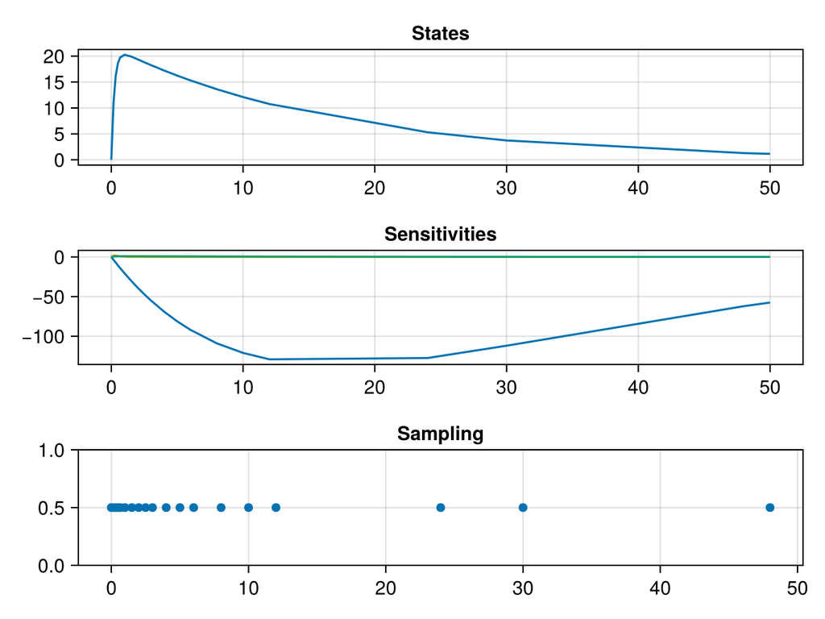

```julia
ps, st = LuxCore.setup(Random.default_rng(), oed)

sol, _ = oed(nothing, ps, st)

function plot_oed(sol, sampling)
    f = Figure()
    ax = CairoMakie.Axis(f[1, 1], xticks = 0:10:50, title = "States")
    ax2 = CairoMakie.Axis(f[2, 1], xticks = 0:10:50, title = "Sensitivities")
    ax3 = CairoMakie.Axis(f[3, 1], xticks = 0:10:50, title = "Sampling")
    plot!(ax, sol, idxs = [1])
    plot!(ax2, sol, idxs = [2, 3, 4])
    scatter!(ax3, measurement_points, sampling)
    return f
end

plot_oed(sol, ps.controls)
```

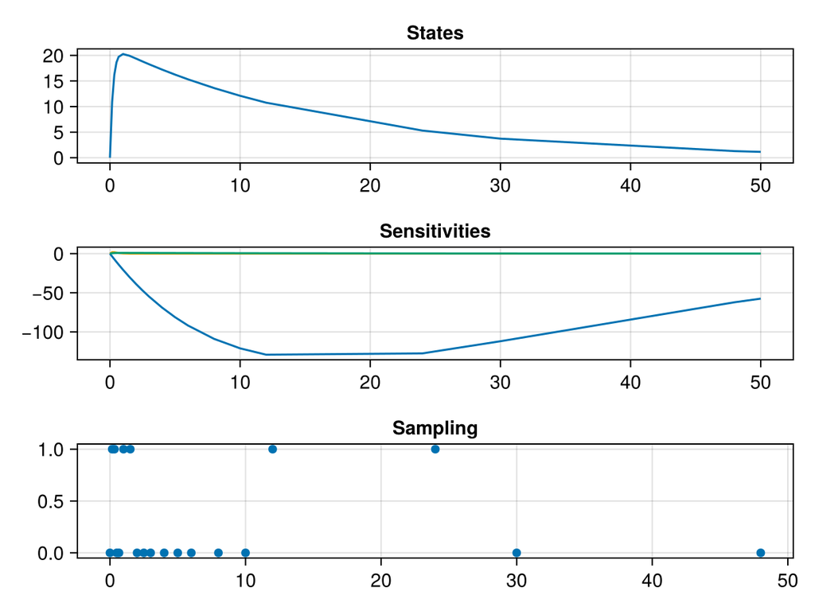

```julia
optprob = OptimizationProblem(oed, DCriterion(); M = [6.0])

uopt = solve(
    optprob, Ipopt.Optimizer(),
    tol = 1.0e-12,
    hessian_approximation = "limited-memory",
    max_iter = 100,
)

optu = uopt.u + zero(ComponentArray(ps))
sol, _ = oed(nothing, optu, st)

plot_oed(sol, optu.controls)
```

## Integer sampling decisions

Even though optimal solutions to OED problems tend to have integer solutions if the discretization grid is chosen adequately, sometimes it might be necessary to enforce integrality of the sampling decisions and include it in the problem formulation. This is also possible in Corleone. This is possible by passing `integer_weights = true` to the OptimizationProblem constructor.

```julia
optprob = OptimizationProblem(oed, DCriterion(); M = [6.0], integer_weights = true)
```

```
OptimizationProblem. In-place: true
u0: 22-element Vector{Float64}:
  0.05884
  4.298
 21.8
  0.5
  0.5
  0.5
  0.5
  0.5
  0.5
  0.5
  0.5
  0.5
  0.5
  0.5
  0.5
  0.5
  0.5
  0.5
  0.5
  0.5
  0.5
  0.5
```

This problem must then be solved by a suitable MINLP solver. In this case, we use Juniper.

```julia
using Juniper

opt = OptimizationMOI.MOI.OptimizerWithAttributes(
    Juniper.Optimizer,
    "nl_solver" => OptimizationMOI.MOI.OptimizerWithAttributes(
        Ipopt.Optimizer,
        "print_level" => 0,
    )
)

sol = solve(optprob, opt)
```

```
retcode: Success
u: 22-element Vector{Float64}:
  0.05884
  4.298
 21.8
  0.0
  1.0
  1.0
  0.0
  0.0
  2.5417531639423497e-8
  1.0
  1.0
  0.0
  0.0
  0.0
  0.0
  0.0
  0.0
  0.0
  1.0
  1.0
  0.0
  0.0
```

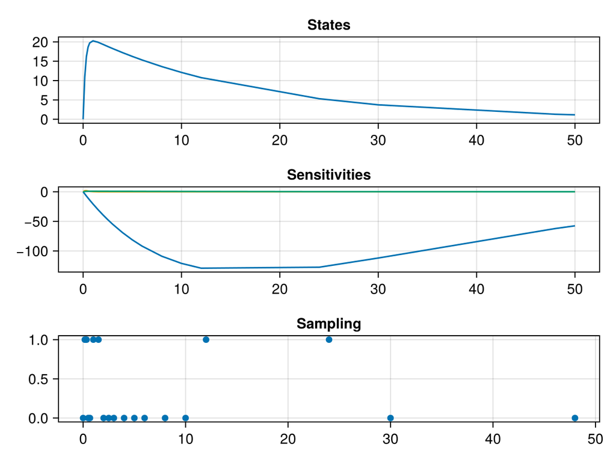

```julia
optu = uopt.u + zero(ComponentArray(ps))
sol, _ = oed(nothing, optu, st)

plot_oed(sol, optu.controls)
```

## Appendix

**This example was built using these direct dependencies,**

```julia
        using Pkg
        Pkg.status()
```

```
Status `~/work/Corleone.jl/Corleone.jl/docs/Project.toml`
  [13f3f980] CairoMakie v0.15.10
  [b0b7db55] ComponentArrays v0.15.38
  [2751e0db] Corleone v0.0.3 `~/work/Corleone.jl/Corleone.jl`
  [6590a4b1] CorleoneOED v0.0.4
  [e30172f5] Documenter v1.17.0
  [daee34ce] DocumenterCitations v1.4.1
  [d12716ef] DocumenterInterLinks v1.1.0
  [f6369f11] ForwardDiff v1.3.3
  [b6b21f68] Ipopt v1.14.3
  [682c06a0] JSON v1.6.0
  [2ddba703] Juniper v0.9.4
  [98b081ad] Literate v2.21.0
  [bb33d45b] LuxCore v1.5.3
  [961ee093] ModelingToolkit v11.26.3
  [7f7a1694] Optimization v5.6.1
  [22f7324a] OptimizationLBFGSB v1.4.1
  [fd9f6733] OptimizationMOI v1.3.1
⌃ [b1df2697] OrdinaryDiffEqTsit5 v1.12.0
  [2efcf032] SymbolicIndexingInterface v0.3.47
  [ddb6d928] YAML v0.4.16
  [9a3f8284] Random v1.11.0
Info Packages marked with ⌃ have new versions available and may be upgradable.
```

**and using this machine and Julia version.**

```julia
        using InteractiveUtils
        InteractiveUtils.versioninfo()
```

```
Julia Version 1.12.6
Commit 15346901f00 (2026-04-09 19:20 UTC)
Build Info:
  Official https://julialang.org release
Platform Info:
  OS: Linux (x86_64-linux-gnu)
  CPU: 4 × AMD EPYC 7763 64-Core Processor
  WORD_SIZE: 64
  LLVM: libLLVM-18.1.7 (ORCJIT, znver3)
  GC: Built with stock GC
Threads: 1 default, 1 interactive, 1 GC (on 4 virtual cores)
```

**A more complete overview of all dependencies and their versions is also provided.**

```julia
        using Pkg
        Pkg.status(; mode = PKGMODE_MANIFEST)
```

[output not shown]

[output not shown]

*This page was generated using Literate.jl.*